# ML-KenwanCheung-DogNet-V3

## Kenwan Cheung - Machine Learning - Final Project

### Catnet - Detecting images of cats - classification project.

**Goal:**

The goal of this project is to reapproach one of the original kaggle datasets - Dogs vs Cats image classification.

**Early discussion:**

Image classification has become a very interesting application space with the rise of convolutional neural nets. That being said, I wanted to take the opportunity to both apply CNNs as well as compare their results vs that of other ML methods.

However, I wanted to tackle this problem set knowing that I have a limited max of computing power due to having a mobile laptop as well as having no GPUs to speed up the process.

Thus for our CNN in particular, we had to undergo some data augmentation.

**Methodology:**

We will attempt to classify the images with a variety of approaches:

1. K-Nearest Neighbors
2. Tree based approaches (RF / GBT)
3. SVMs
4. A CNN approach

**Evaluation:**

We'll use the standard evaluation techniques across models. ROC curves (true vs false positive), AUC values, accuracy and sensitivity etc...

**Summary:**

In the end, the tree based models performed very well on a histogram of pixel intensity. The lack of a large training set meant that some promising validation test values of 80%+ did not translate into our test set outside of the validation results.

That being said, we can see the promise in the CNN application. We did not do much fine tuning, nor go to the depth that we could.

The CNN technology we're using is from 2014, which is an eternity in the field of deep learning. Current innovations have included ever deeper networks, different activation functions that are asymptotic to 0 rather than ReLu (0,max), as well as residual neural networks where we incorporate fits on weights to the residuals rather purely on the original mapping.

Despite this project, there is much much more to learn!

### Early Prep

```python
# Import relevant packages

%matplotlib inline
from sklearn import datasets, neighbors
import numpy as np
import pandas as pd
import matplotlib.pyplot as plt
import seaborn as sns
from sklearn.model_selection import cross_val_score, GridSearchCV,KFold, RandomizedSearchCV
from sklearn.metrics import confusion_matrix, accuracy_score, classification_report, roc_curve, roc_auc_score
from sklearn.cross_validation import train_test_split
from sklearn.ensemble import RandomForestClassifier, GradientBoostingClassifier
from sklearn.neighbors import KNeighborsClassifier
from imutils import paths
from keras.models import Sequential
from keras.layers import Input, Dropout, Flatten, Convolution2D, MaxPooling2D, Dense, Activation, Conv2D, ZeroPadding2D
from keras.optimizers import RMSprop, adam
from keras.callbacks import ModelCheckpoint, Callback, EarlyStopping
from keras.utils import np_utils
from keras.preprocessing.image import ImageDataGenerator, array_to_img, img_to_array, load_img
from keras import backend as K
from keras.metrics import binary_accuracy,binary_crossentropy
from tqdm import tqdm
from IPython.display import SVG
from keras.utils.vis_utils import model_to_dot
from keras.regularizers import l2 # L2-regularisation
from keras.layers.normalization import BatchNormalization # batch normalisation
from sklearn import svm
import random
import argparse
import datetime
import imutils
import cv2
import os
import re
import shutil
K.set_image_dim_ordering('th')
```

```python
# image to vector
def image_to_feature_vector(image, size=(150,150)):
    # resize, flatten
    return cv2.resize(image,size).flatten()
```

```python
# color hist
def extract_color_histogram(image, bins=(8,8,8)):
    hsv = cv2.cvtColor(image, cv2.COLOR_BGR2HSV)
    hist = cv2.calcHist([hsv],[0,1,2], None, bins,
                       [0,180,0,256,0,256])
    if imutils.is_cv2():
        hist = cv2.normalize(hist)
    else:
        cv2.normalize(hist,hist)
    return hist.flatten()
```

Some functions for NN are below.

```python
def read_image(file_path):
    img = cv2.imread(file_path, cv2.IMREAD_COLOR) #cv2.IMREAD_GRAYSCALE
    return cv2.resize(img, (ROWS, COLS))#, interpolation=cv2.INTER_CUBIC)

def prep_data(images):
    count = len(images)
    data = np.ndarray((count, CHANNELS, ROWS, COLS), dtype=np.uint8)

    for i, image_file in enumerate(images):
        image = read_image(image_file)
        data[i] = image.T
        if i%250 == 0: print('Processed {} of {}'.format(i, count))

    return data
```

Image path loading below

```python
# get images
print("[INFO] Getting images locations...")
imagePaths = list(paths.list_images("train/"))
count = len(imagePaths)
print("[INFO] Count of images in folder: {}".format(count))

# init lists to store
rawImages_train = []
features_train = []
labels_train = []

rawImages_test = []
features_test = []
labels_test = []
```

```
[INFO] Getting images locations...
[INFO] Count of images in folder: 25000
```

```python
# params of nn

ROWS = 150
COLS = 150
CHANNELS = 3
data = np.ndarray((count, CHANNELS, ROWS, COLS), dtype=np.uint8)
```

```python
# segmenting into even classes

DOG_TRAIN_DIR = 'data/train/dog/'
CAT_TRAIN_DIR = 'data/train/cat/'
DOG_TEST_DIR = 'data/test/dog/'
CAT_TEST_DIR = 'data/test/cat/'

# train_images = [TRAIN_DIR+i for i in os.listdir(TRAIN_DIR)] # use this for full dataset
train_dogs =   [DOG_TRAIN_DIR+i for i in os.listdir(DOG_TRAIN_DIR) if 'dog' in i]
train_cats =   [CAT_TRAIN_DIR+i for i in os.listdir(CAT_TRAIN_DIR) if 'cat' in i]
test_dogs = [DOG_TEST_DIR+i for i in os.listdir(DOG_TEST_DIR) if 'dog' in i]
test_cats = [CAT_TEST_DIR+i for i in os.listdir(CAT_TEST_DIR) if 'cat' in i]

# slice datasets for memory efficiency on Kaggle Kernels, delete if using full dataset
train_images = train_dogs + train_cats
random.shuffle(train_images)

test_images =  test_dogs + test_cats
random.shuffle(test_images)

train = prep_data(train_images)
test = prep_data(test_images)

print("Train shape: {}".format(train.shape))
print("Test shape: {}".format(test.shape))
```

```
Processed 0 of 2000
Processed 250 of 2000
Processed 500 of 2000
Processed 750 of 2000
Processed 1000 of 2000
Processed 1250 of 2000
Processed 1500 of 2000
Processed 1750 of 2000
Processed 0 of 800
Processed 250 of 800
Processed 500 of 800
Processed 750 of 800
Train shape: (2000, 3, 150, 150)
Test shape: (800, 3, 150, 150)
```

```python
print(train_dogs[0])
print(train_dogs[0:1])
```

```
data/train/dog/dog.0.jpg
['data/train/dog/dog.0.jpg']
```

### Now let's process the images for non NN applications - we have train and test for the truncated data set

```python
# now to extract the features for train
for(i, imagePath) in enumerate(train_images):
#     print(i, imagePath)

    # load
    image = cv2.imread(imagePath)
    label = imagePath.split(os.path.sep)[-1].split(".")[0]

    # extract
    pixels = image_to_feature_vector(image)
    hist = extract_color_histogram(image)

    # update lists
    rawImages_train.append(pixels)
    features_train.append(hist)
    if label == "cat":
        labels_train.append(0)
    else:
        labels_train.append(1)

    # status update
    if i>0 and i % 250 == 0:
        print("[INFO] Train processed {}/{}".format(i,len(train_images)))
```

```
[INFO] Train processed 250/2000
[INFO] Train processed 500/2000
[INFO] Train processed 750/2000
[INFO] Train processed 1000/2000
[INFO] Train processed 1250/2000
[INFO] Train processed 1500/2000
[INFO] Train processed 1750/2000
```

```python
print(len(labels_train))
print(labels_train[0:5])
```

```
2000
[0, 0, 0, 1, 1]
```

```python
# now to extract the features for train
for(i, imagePath) in enumerate(test_images):
#     print(i, imagePath)

    # load
    image = cv2.imread(imagePath)
    label = imagePath.split(os.path.sep)[-1].split(".")[0]

    # extract
    pixels = image_to_feature_vector(image)
    hist = extract_color_histogram(image)

    # update lists
    rawImages_test.append(pixels)
    features_test.append(hist)
    if label == "cat":
        labels_test.append(0)
    else:
        labels_test.append(1)

    # status update
    if i>0 and i % 250 == 0:
        print("[INFO] Train processed {}/{}".format(i,len(test_images)))
```

```
[INFO] Train processed 250/800
[INFO] Train processed 500/800
[INFO] Train processed 750/800
```

```python
print(len(labels_test))
print(labels_test[0:5])
```

```
800
[0, 0, 0, 0, 0]
```

```python
len(rawImages_train)
```

```
2000
```

### Let's look at the class balance

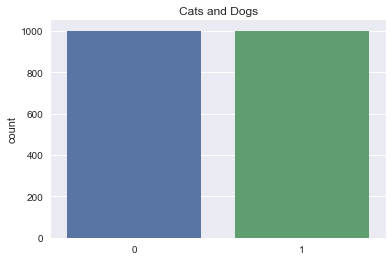

```python
sns.countplot(labels_train)
sns.plt.title('Cats and Dogs')
```

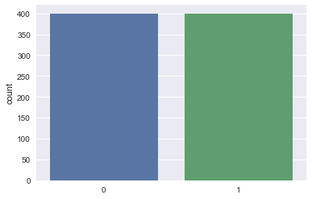

```python
sns.countplot(labels_test)
```

### Continue some early previewing to better know our data

```python
def show_cats_and_dogs(idx):
    dogs = read_image(train_dogs[idx])
    cats = read_image(train_cats[idx])
    pair = np.concatenate((cats, dogs), axis=1)
    plt.figure(figsize=(10,5))
    plt.imshow(pair)
    plt.show()
```

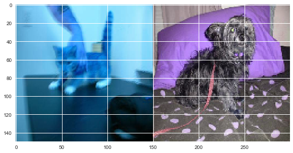

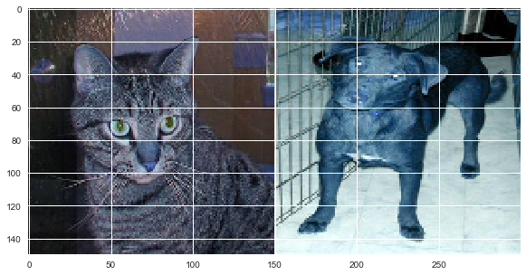

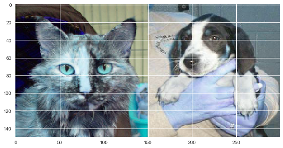

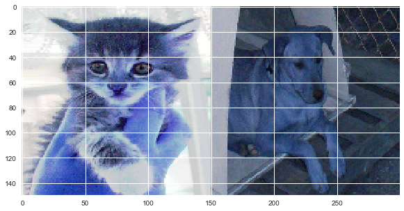

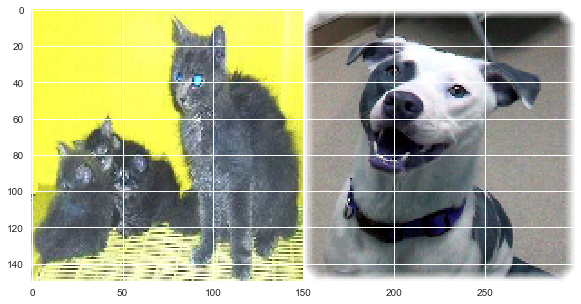

```python
for idx in range(0,5):
#     print(dog_idx[idx])
    show_cats_and_dogs(idx)
```

I prefer the right column! The descaling also does wash out some details.

I tried this sample (without telling the subject that the left side is always a cat) on my girlfriend and she achieved a ~90% accuracy.

### Our first model to fit is KNN

Let's first run it manually without CV.

```python
# let's grid search across our range of values
neighbors = 2
cv_scores = []

for k in range(1,neighbors):
    print("[INFO] Fitting with {} Neighbors".format(k))
    print(k)
    knn = KNeighborsClassifier(n_neighbors=neighbors,
                             n_jobs=-1)
    knn.fit(features_train,labels_train)
    acc = knn.score(features_test, labels_test)
    print("[INFO] histogram accuracy {:.2f}%".format(acc*100))
```

```
[INFO] Fitting with 1 Neighbors
1
[INFO] histogram accuracy 57.25%
```

###### Now CV - We know that a single K accuracy is ~57% (varies with each run), which is not great. What happens if we do multiple fits with CV, and grid search for various K vaues?

```python
# let's grid search across our range of values
neighbors = 2
cv_scores = []

for k in range(1,neighbors):
    print("[INFO] Fitting with {} Neighbors".format(k))
    start = datetime.datetime.now()
    print(start)
    knn = KNeighborsClassifier(n_neighbors=neighbors,
                             n_jobs=-1)
    scores = cross_val_score(knn, features_train, labels_train, cv=5, scoring='accuracy')
    cv_scores.append(scores.mean())
    print("[INFO] histogram accuracy {}%".format(cv_scores))
    end = datetime.datetime.now()
    print(end)
    tdelta = end - start
    print("[INFO] time duration {}".format(divmod(tdelta.total_seconds(), 60)))
```

```
[INFO] Fitting with 1 Neighbors
2017-12-02 11:17:43.716517
[INFO] histogram accuracy [0.57700000000000007]%
2017-12-02 11:17:45.639259
[INFO] time duration (0.0, 1.922742)
```

Now let's repeat the process with more K values. This could take some time!

```python
# let's grid search across our range of values
neighbors = [1,2,3,4,5,10,15,30,50]
cv_scores = []

for k in range(0,len(neighbors)):
    print("[INFO] Fitting with {} Neighbors".format(neighbors[k]))
    start = datetime.datetime.now()
    print(start)
    knn = KNeighborsClassifier(n_neighbors=neighbors[k],
                             n_jobs=-1)
    scores = cross_val_score(knn, features_train, labels_train, cv=5, scoring='accuracy')
    cv_scores.append(scores.mean())
    print("[INFO] histogram accuracy {}%".format(cv_scores[k]))
    end = datetime.datetime.now()
    print(end)
    tdelta = end-start
    print("[INFO] time duration {}".format(divmod(tdelta.total_seconds(), 60)))
```

```
[INFO] Fitting with 1 Neighbors
2017-12-02 11:17:50.965490
[INFO] histogram accuracy 0.583%
2017-12-02 11:17:52.867398
[INFO] time duration (0.0, 1.901908)
[INFO] Fitting with 2 Neighbors
2017-12-02 11:17:52.867516
[INFO] histogram accuracy 0.5770000000000001%
2017-12-02 11:17:54.753554
[INFO] time duration (0.0, 1.886038)
[INFO] Fitting with 3 Neighbors
2017-12-02 11:17:54.753795
[INFO] histogram accuracy 0.5715%
2017-12-02 11:17:56.531984
[INFO] time duration (0.0, 1.778189)
[INFO] Fitting with 4 Neighbors
2017-12-02 11:17:56.532198
[INFO] histogram accuracy 0.5725%
2017-12-02 11:17:58.324584
[INFO] time duration (0.0, 1.792386)
[INFO] Fitting with 5 Neighbors
2017-12-02 11:17:58.324798
[INFO] histogram accuracy 0.5850000000000001%
2017-12-02 11:18:00.133748
[INFO] time duration (0.0, 1.80895)
[INFO] Fitting with 10 Neighbors
2017-12-02 11:18:00.135080
[INFO] histogram accuracy 0.5745%
2017-12-02 11:18:02.031673
[INFO] time duration (0.0, 1.896593)
[INFO] Fitting with 15 Neighbors
2017-12-02 11:18:02.031868
[INFO] histogram accuracy 0.5815%
2017-12-02 11:18:03.837256
[INFO] time duration (0.0, 1.805388)
[INFO] Fitting with 30 Neighbors
2017-12-02 11:18:03.838392
[INFO] histogram accuracy 0.59%
2017-12-02 11:18:05.642825
[INFO] time duration (0.0, 1.804433)
[INFO] Fitting with 50 Neighbors
2017-12-02 11:18:05.643064
[INFO] histogram accuracy 0.606%
2017-12-02 11:18:07.436978
[INFO] time duration (0.0, 1.793914)
```

We can see the change in accuracy with various parameters in converting the histogram of features into a final prediction.

Let's continue on.

```python
# with neighbors from cv.
knn_final = KNeighborsClassifier(n_neighbors=15,
                             n_jobs=-1)
# fit
knn_final.fit(features_train,labels_train)
```

```
KNeighborsClassifier(algorithm='auto', leaf_size=30, metric='minkowski',
           metric_params=None, n_jobs=-1, n_neighbors=15, p=2,
           weights='uniform')
```

```python
knn_preds = knn_final.predict(features_test)
```

```python
final_preds = pd.DataFrame()
final_preds['actual'] = labels_test
final_preds['knn'] = knn_preds
```

```python
accuracy_score(y_pred= final_preds['knn'],y_true=final_preds['actual'])
```

```
0.58625000000000005
```

### Let's try a tree based approach now!

# Note for viewer: this outputs quite a lot of output steps, please skip down for some time (sorry!)

```python
# RF
rf = RandomForestClassifier(n_estimators=1000, criterion='gini', max_depth=None, max_features='sqrt', oob_score=True,
                            n_jobs=4, verbose=0)

# time start
start = datetime.datetime.now()
print("[INFO] Starting RF on {}".format(start))

# fit
rf.fit(features_train,labels_train)

# time end
end = datetime.datetime.now()
print("[INFO] Finished RF on {}".format(end))

tdelta = end-start
print("[INFO] time duration {}".format(divmod(tdelta.total_seconds(), 60)))
```

```
[INFO] Starting RF on 2017-12-04 19:27:15.733276
[INFO] Finished RF on 2017-12-04 19:27:25.939577
[INFO] time duration (0.0, 10.206301)
```

###### Performance validation

```python
rf.get_params
```

[output not shown]

```python
rf_acc = rf.score(features_test, labels_test)
```

```
[Parallel(n_jobs=4)]: Done  33 tasks      | elapsed:    0.0s
[Parallel(n_jobs=4)]: Done 154 tasks      | elapsed:    0.1s
[Parallel(n_jobs=4)]: Done 357 tasks      | elapsed:    0.2s
[Parallel(n_jobs=4)]: Done 640 tasks      | elapsed:    0.4s
[Parallel(n_jobs=4)]: Done 1000 out of 1000 | elapsed:    0.6s finished
```

```python
print(rf_acc)
```

```
0.685
```

Without much hyperparameter tuning - we get a pretty large improvement with that over our KNN approach!

###### Parameter tuning with grid search

Set grid of parameter distributions to search through.

```python
# RF
rf_gs = RandomForestClassifier(oob_score=True,
                            n_jobs=4,
                            verbose=0)

# specify parameters and distributions to sample from
param_dist = {
    'n_estimators': [200, 500, 700, 1000],
    'max_features': ['auto', 'sqrt', 'log2'],
    'max_depth': [1,2,3,5,10],
    'criterion': ['gini','entropy'],
    'min_samples_split': [2,3,4,5],
    'min_samples_leaf': [2,3,4,5],
    'bootstrap': [True]
}

# time start
start = datetime.datetime.now()
print("[INFO] Starting RF on {}".format(start))

# run randomized search
n_iter_search = 20
random_search = RandomizedSearchCV(rf_gs, param_distributions=param_dist,
                                   n_iter=n_iter_search)

random_search.fit(features_train,labels_train)

# time end
end = datetime.datetime.now()
print("[INFO] Finished RF on {}".format(end))

tdelta = end-start
print("[INFO] time duration {}".format(divmod(tdelta.total_seconds(), 60)))
```

```
[INFO] Starting RF on 2017-12-04 19:27:41.758630
[INFO] Finished RF on 2017-12-04 19:31:44.425453
[INFO] time duration (4.0, 2.6668229999999937)
```

```python
random_search.best_estimator_
```

```
RandomForestClassifier(bootstrap=True, class_weight=None, criterion='gini',
            max_depth=10, max_features='auto', max_leaf_nodes=None,
            min_impurity_split=1e-07, min_samples_leaf=4,
            min_samples_split=3, min_weight_fraction_leaf=0.0,
            n_estimators=500, n_jobs=4, oob_score=True, random_state=None,
            verbose=2, warm_start=False)
```

```python
random_search.cv_results_
```

[output not shown]

[output cut: 175 more lines]

[output not shown]

```python
random_search.best_score_
```

```
0.67349999999999999
```

###### Setting predictions

```python
rf_preds = rf.predict(features_test)
final_preds['rf'] = rf_preds
```

```
[Parallel(n_jobs=4)]: Done  33 tasks      | elapsed:    0.0s
[Parallel(n_jobs=4)]: Done 154 tasks      | elapsed:    0.1s
[Parallel(n_jobs=4)]: Done 357 tasks      | elapsed:    0.2s
[Parallel(n_jobs=4)]: Done 640 tasks      | elapsed:    0.4s
[Parallel(n_jobs=4)]: Done 1000 out of 1000 | elapsed:    0.6s finished
```

```python
final_preds.head()
```

|  | actual | knn | rf |
| --- | --- | --- | --- |
| 0 | 1 | 0 | 1 |
| 1 | 1 | 0 | 0 |
| 2 | 0 | 0 | 0 |
| 3 | 1 | 0 | 1 |
| 4 | 1 | 1 | 1 |

```python
accuracy_score(y_pred=final_preds['rf'], y_true=final_preds['actual'])
```

```
0.68500000000000005
```

### Let's try an SVM classifier

```python
svm_model = svm.SVC(kernel='linear', C=1, gamma=1)
svm_model.fit(features_train,labels_train)
```

```
SVC(C=1, cache_size=200, class_weight=None, coef0=0.0,
  decision_function_shape=None, degree=3, gamma=1, kernel='linear',
  max_iter=-1, probability=False, random_state=None, shrinking=True,
  tol=0.001, verbose=False)
```

```python
final_preds['svm'] = svm_model.predict(features_test)
```

```python
accuracy_score(y_true = final_preds['actual'], y_pred=final_preds['svm'])
```

```
0.64000000000000001
```

SVM first pass is pretty good as well!

```python
svm_model_rbf = svm.SVC(kernel="rbf", C=1, gamma=1)
svm_model_rbf.fit(features_train,labels_train)
```

```
SVC(C=1, cache_size=200, class_weight=None, coef0=0.0,
  decision_function_shape=None, degree=3, gamma=1, kernel='rbf',
  max_iter=-1, probability=False, random_state=None, shrinking=True,
  tol=0.001, verbose=False)
```

```python
accuracy_score(y_true = final_preds['actual'], y_pred=svm_model_rbf.predict(features_test))
```

```
0.64249999999999996
```

#### So the two are roughly similar.

Let's now do some parameter hypertuning with grid search.

```python
# Set the parameters by cross-validation
tuned_parameters = [{'kernel': ['rbf'], 'gamma': [1e-3, 1e-4],
                     'C': [1, 10, 100, 1000]},
                    {'kernel': ['linear'], 'C': [1, 10, 100, 1000]}]
tuned_parameters
```

```
[{'C': [1, 10, 100, 1000], 'gamma': [0.001, 0.0001], 'kernel': ['rbf']},
 {'C': [1, 10, 100, 1000], 'kernel': ['linear']}]
```

```python
scores = ['precision', 'recall']

for score in scores:
    print("# Tuning hyper-parameters for %s" % score)
    print()

    svm_cv = GridSearchCV(svm.SVC(), tuned_parameters, cv=5,
                       scoring='%s_macro' % score)
    svm_cv.fit(features_train, labels_train)

    print("Best parameters set found on development set:")
    print()
    print(svm_cv.best_params_)
    print()
    print("Grid scores on development set:")
    print()
    means = svm_cv.cv_results_['mean_test_score']
    stds = svm_cv.cv_results_['std_test_score']
    for mean, std, params in zip(means, stds, svm_cv.cv_results_['params']):
        print("%0.3f (+/-%0.03f) for %r"
              % (mean, std * 2, params))
    print()

    print("Detailed classification report:")
    print()
    print("The model is trained on the full development set.")
    print("The scores are computed on the full evaluation set.")
    print()
    y_true, y_pred = labels_test, svm_cv.predict(features_test)
    print(classification_report(y_true, y_pred))
    print()
```

```
# Tuning hyper-parameters for precision

Best parameters set found on development set:

{'gamma': 0.001, 'kernel': 'rbf', 'C': 1000}

Grid scores on development set:

0.604 (+/-0.043) for {'gamma': 0.001, 'kernel': 'rbf', 'C': 1}
0.604 (+/-0.043) for {'gamma': 0.0001, 'kernel': 'rbf', 'C': 1}
0.604 (+/-0.043) for {'gamma': 0.001, 'kernel': 'rbf', 'C': 10}
0.604 (+/-0.043) for {'gamma': 0.0001, 'kernel': 'rbf', 'C': 10}
0.618 (+/-0.043) for {'gamma': 0.001, 'kernel': 'rbf', 'C': 100}
0.604 (+/-0.043) for {'gamma': 0.0001, 'kernel': 'rbf', 'C': 100}
0.620 (+/-0.063) for {'gamma': 0.001, 'kernel': 'rbf', 'C': 1000}
0.617 (+/-0.045) for {'gamma': 0.0001, 'kernel': 'rbf', 'C': 1000}
0.616 (+/-0.062) for {'kernel': 'linear', 'C': 1}
0.614 (+/-0.041) for {'kernel': 'linear', 'C': 10}
0.606 (+/-0.028) for {'kernel': 'linear', 'C': 100}
0.594 (+/-0.049) for {'kernel': 'linear', 'C': 1000}

Detailed classification report:

The model is trained on the full development set.
The scores are computed on the full evaluation set.

             precision    recall  f1-score   support

          0       0.62      0.70      0.65       400
          1       0.65      0.56      0.60       400

avg / total       0.63      0.63      0.63       800


# Tuning hyper-parameters for recall

Best parameters set found on development set:

{'gamma': 0.001, 'kernel': 'rbf', 'C': 1000}

```

[output cut: 11 more lines]

```
0.614 (+/-0.041) for {'kernel': 'linear', 'C': 10}
0.606 (+/-0.029) for {'kernel': 'linear', 'C': 100}
0.593 (+/-0.050) for {'kernel': 'linear', 'C': 1000}

Detailed classification report:

The model is trained on the full development set.
The scores are computed on the full evaluation set.

             precision    recall  f1-score   support

          0       0.62      0.70      0.65       400
          1       0.65      0.56      0.60       400

avg / total       0.63      0.63      0.63       800
```

```python
final_preds['svm'] = svm_cv.predict(features_test)
final_preds.head()
```

[output not shown]

```python
accuracy_score(y_true = final_preds['actual'], y_pred=svm_cv.predict(features_test))
```

```
0.63124999999999998
```

### Now we can move onto another tree approach. Gradient boosted trees. GBTs are great, and build many shallow trees.

```python
gbt = GradientBoostingClassifier(learning_rate=0.1, n_estimators=1000, max_depth=3)
```

```python
# fit the gbt
gbt.fit(features_train, labels_train)

gbt_test_preds = gbt.predict(features_test)
```

[output not shown]

[output cut: 20 more lines]

```python
final_preds['gbt'] = gbt_test_preds
accuracy_score(y_true = final_preds['actual'], y_pred=gbt_test_preds)
```

```
0.68000000000000005
```

Without optimization, GBT performed really well! Tree based approaches seem to perform excellently (GBT).

Grid search optimization of GBT below.

```python
# gbt_params = GradientBoostingClassifier(n_estimators=200,
#                                  max_depth=1,
#                                  subsample=0.5,
#                                  max_features=0.5,
#                                  learning_rate=0.02)

# param_grid = {"n_estimators": [50,200,400,1000],
#               "max_depth": [1, 3, 8],
#               'learning_rate': [0.1, 0.2, 1.]}

# gbt_cv = GridSearchCV(gbt_params,
#                                param_grid,
#                                cv=3,
#                                scoring='roc_auc',
#                                n_jobs=8)
# gbt_cv.fit(features_train, labels_train)

print("Best parameter set found on development set:")
print()
print(gbt_cv.best_estimator_)
print()
print("Grid scores on a subset of the development set:")

for params, mean_score, scores in gbt_cv.grid_scores_:
    print("%0.4f (+/-%0.04f) for %r"%(mean_score, scores.std(), params))

print("With the model trained on the full development set:")
print()
y_true, y_pred = labels_test, gbt_cv.predict(features_test)
print("  It scores %0.4f on the test set"%roc_auc_score(y_true, y_pred))
print()
print(classification_report(y_true, y_pred))
print()
```

```
Best parameter set found on development set:

GradientBoostingClassifier(criterion='friedman_mse', init=None,
              learning_rate=0.1, loss='deviance', max_depth=8,
              max_features=0.5, max_leaf_nodes=None,
              min_impurity_split=1e-07, min_samples_leaf=1,
              min_samples_split=2, min_weight_fraction_leaf=0.0,
              n_estimators=400, presort='auto', random_state=None,
              subsample=0.5, verbose=0, warm_start=False)

Grid scores on a subset of the development set:
0.7132 (+/-0.0138) for {'max_depth': 1, 'learning_rate': 0.1, 'n_estimators': 50}
0.7395 (+/-0.0064) for {'max_depth': 1, 'learning_rate': 0.1, 'n_estimators': 200}
0.7410 (+/-0.0077) for {'max_depth': 1, 'learning_rate': 0.1, 'n_estimators': 400}
0.7205 (+/-0.0164) for {'max_depth': 1, 'learning_rate': 0.1, 'n_estimators': 1000}
0.7271 (+/-0.0073) for {'max_depth': 3, 'learning_rate': 0.1, 'n_estimators': 50}
0.7408 (+/-0.0165) for {'max_depth': 3, 'learning_rate': 0.1, 'n_estimators': 200}
0.7348 (+/-0.0174) for {'max_depth': 3, 'learning_rate': 0.1, 'n_estimators': 400}
0.7351 (+/-0.0085) for {'max_depth': 3, 'learning_rate': 0.1, 'n_estimators': 1000}
0.7318 (+/-0.0073) for {'max_depth': 8, 'learning_rate': 0.1, 'n_estimators': 50}
0.7376 (+/-0.0073) for {'max_depth': 8, 'learning_rate': 0.1, 'n_estimators': 200}
0.7452 (+/-0.0138) for {'max_depth': 8, 'learning_rate': 0.1, 'n_estimators': 400}
0.7436 (+/-0.0087) for {'max_depth': 8, 'learning_rate': 0.1, 'n_estimators': 1000}
0.7254 (+/-0.0147) for {'max_depth': 1, 'learning_rate': 0.2, 'n_estimators': 50}
0.7238 (+/-0.0064) for {'max_depth': 1, 'learning_rate': 0.2, 'n_estimators': 200}
0.7160 (+/-0.0117) for {'max_depth': 1, 'learning_rate': 0.2, 'n_estimators': 400}
0.7063 (+/-0.0064) for {'max_depth': 1, 'learning_rate': 0.2, 'n_estimators': 1000}
0.7229 (+/-0.0173) for {'max_depth': 3, 'learning_rate': 0.2, 'n_estimators': 50}
0.7258 (+/-0.0207) for {'max_depth': 3, 'learning_rate': 0.2, 'n_estimators': 200}
0.7350 (+/-0.0140) for {'max_depth': 3, 'learning_rate': 0.2, 'n_estimators': 400}
0.7264 (+/-0.0123) for {'max_depth': 3, 'learning_rate': 0.2, 'n_estimators': 1000}
0.7179 (+/-0.0042) for {'max_depth': 8, 'learning_rate': 0.2, 'n_estimators': 50}
0.7384 (+/-0.0081) for {'max_depth': 8, 'learning_rate': 0.2, 'n_estimators': 200}
0.7303 (+/-0.0154) for {'max_depth': 8, 'learning_rate': 0.2, 'n_estimators': 400}
0.7343 (+/-0.0143) for {'max_depth': 8, 'learning_rate': 0.2, 'n_estimators': 1000}
0.6601 (+/-0.0213) for {'max_depth': 1, 'learning_rate': 1.0, 'n_estimators': 50}
0.6218 (+/-0.0328) for {'max_depth': 1, 'learning_rate': 1.0, 'n_estimators': 200}
0.5721 (+/-0.0171) for {'max_depth': 1, 'learning_rate': 1.0, 'n_estimators': 400}
0.5206 (+/-0.0277) for {'max_depth': 1, 'learning_rate': 1.0, 'n_estimators': 1000}
0.6261 (+/-0.0033) for {'max_depth': 3, 'learning_rate': 1.0, 'n_estimators': 50}
0.5455 (+/-0.0117) for {'max_depth': 3, 'learning_rate': 1.0, 'n_estimators': 200}
0.5406 (+/-0.0384) for {'max_depth': 3, 'learning_rate': 1.0, 'n_estimators': 400}
0.5302 (+/-0.0099) for {'max_depth': 3, 'learning_rate': 1.0, 'n_estimators': 1000}
0.6112 (+/-0.0063) for {'max_depth': 8, 'learning_rate': 1.0, 'n_estimators': 50}
0.5757 (+/-0.0089) for {'max_depth': 8, 'learning_rate': 1.0, 'n_estimators': 200}
0.5494 (+/-0.0117) for {'max_depth': 8, 'learning_rate': 1.0, 'n_estimators': 400}
0.5167 (+/-0.0243) for {'max_depth': 8, 'learning_rate': 1.0, 'n_estimators': 1000}
With the model trained on the full development set:

  It scores 0.6987 on the test set

             precision    recall  f1-score   support

          0       0.69      0.72      0.71       400
          1       0.71      0.67      0.69       400

avg / total       0.70      0.70      0.70       800
```

```python
final_preds['gbt'] = y_pred
accuracy_score(y_pred=final_preds['actual'],y_true=final_preds['gbt'])
```

```
0.69874999999999998
```

### Let's try a neural net application, now.

##### Some early set up

Let's do some preprocessing to obfuscate the images and artificially increase the sample of images. Each one will get tweaked and then run through again.

```python
# datagen parameters
datagen = ImageDataGenerator(
        rotation_range=40,
        width_shift_range=0.2,
        height_shift_range=0.2,
        rescale=1./255,
        shear_range=0.2,
        zoom_range=0.2,
        horizontal_flip=True,
        fill_mode='nearest')
```

```python
train_images[0]
```

[output not shown]

```python
img = load_img(train_images[0])
x = img_to_array(img)  # this is a Numpy array with shape (3, 150, 150)
x = x.reshape((1,) + x.shape)  # this is a Numpy array with shape (1, 3, 128, 128)

# the .flow() command below generates batches of randomly transformed images
i = 0
for batch in datagen.flow(x, batch_size=1,
                          save_to_dir='preview', save_prefix='cat', save_format='jpeg'):
    i += 1
    if i > 20:
        break  # otherwise the generator would loop indefinitely
```

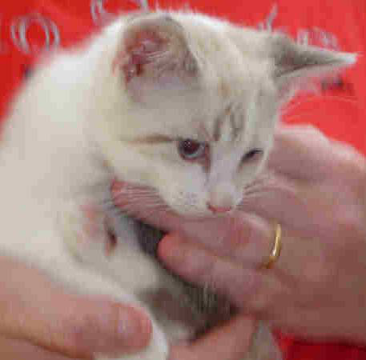

```python
img
```

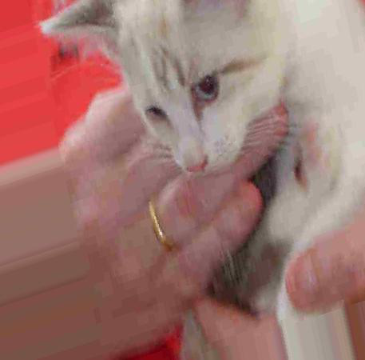

```python
img_altered = load_img('../dognet-final/preview/cat_0_831.jpeg')
img_altered
```

### Data augmentation comments

We can see what the augmentation generator is doing. It will stretch, flip, rotate, etc...

This allows us to artificially increase the size of our small dataset (for a NN).

### Some general comments on NN

Neural nets take a lot of computing power to train. I do not have those capabilities. As such I am a little constrained with data, which impacts the effectiveness as a method. Still, some valuable learnigns are generate.

The ideal would be to have a deep and long running network, but based on the limitations of my laptop, that might not be feasible.

A deeper but less iterated network also has some issues with overfits as well.

### Additional comments about steps below:

I've tried many different iterations (essentially manual grid searching) as best as I can. Only some of them are listed below.

Depth, width, # of runs, normalization vs not... These combinations are the things tackled below

```python
# Define loss history

## Callback for loss logging per epoch
class LossHistory(Callback):
    def on_train_begin(self, logs={}):
        self.losses = []
        self.val_losses = []

    def on_epoch_end(self, batch, logs={}):
        self.losses.append(logs.get('loss'))
        self.val_losses.append(logs.get('val_loss'))
```

#### Some additional tweaks

We're going to do some additional transformation to augment our small image size of ~2000 images in the train. Normally we'd want to scale this even higher, but for th esake of raw computer power, we're not going to.

```python
batch_size = 16

# this is the augmentation configuration we will use for training
train_datagen = ImageDataGenerator(
        rescale=1./255,
        shear_range=0.2,
        zoom_range=0.2,
        horizontal_flip=True)

# this is the augmentation configuration we will use for testing:
# only rescaling
test_datagen = ImageDataGenerator(rescale=1./255)

# this is a generator that will read pictures found in
# subfolers of train and create augmented data
train_generator = train_datagen.flow_from_directory(
        '../dognet-final/data/train/',  # this is the target directory
        target_size=(150, 150),  # all images will be resized to 150x150
        batch_size=batch_size,
        class_mode='binary')  # since we use binary_crossentropy loss, we need binary labels

# this is a similar generator, for validation data, but we only rescale.
validation_generator = test_datagen.flow_from_directory(
        '../dognet-final/data/validation/',
        target_size=(150, 150),
        batch_size=batch_size,
        class_mode='binary')

# test final with order same
test_generator = test_datagen.flow(
        test,
        labels_test,
#         target_size=(150, 150),
        batch_size=batch_size,
        shuffle=False)

early_stopping = EarlyStopping(monitor='val_acc', min_delta=.001, patience=5, verbose=1, mode='auto')
```

```
Found 2000 images belonging to 2 classes.
Found 800 images belonging to 2 classes.
```

```python
# Print quick check
print(validation_generator.class_indices)
```

```
{'dog': 1, 'cat': 0}
```

### First pass - shallow model.

```python
# If we wanted to load existing weights, we would do so below. Loading weights presaved.
# model.load_weights('fifth_try.h5')
```

```python
def dognet():

    model = Sequential()

    # original below
    model.add(Conv2D(32, (3, 3), input_shape=(3, 150, 150)))
    model.add(Activation('relu'))
    model.add(MaxPooling2D(data_format="channels_first", pool_size=(2, 2)))

    model.add(Conv2D(32, (3, 3)))
    model.add(Activation('relu'))
    model.add(MaxPooling2D(data_format="channels_first", pool_size=(2, 2)))

    model.add(Conv2D(64, (3, 3)))
    model.add(Activation('relu'))
    model.add(MaxPooling2D(data_format="channels_first", pool_size=(2, 2)))

    model.add(Flatten())  # this converts our 3D feature maps to 1D feature vectors
    model.add(Dense(64))
    model.add(Activation('relu'))
    model.add(Dropout(0.5))
    model.add(Dense(1))
    model.add(Activation('sigmoid'))

    model.compile(loss='binary_crossentropy',
                  optimizer='rmsprop',
                  metrics=['accuracy'])

    return model


model = dognet()
```

```python
def run_dognet():
    history = LossHistory()
    start = datetime.datetime.now()
    print("[INFO] Starting NN fit on {}".format(start))

    model.fit_generator(
        train_generator,
        steps_per_epoch=2000 // batch_size,
        epochs=50,
        verbose=1,
        validation_data=validation_generator,
        validation_steps=800 // batch_size)

    predictions = model.predict_generator(test_generator,800/batch_size,verbose=1)
    end = datetime.datetime.now()
    print("[INFO] Finished fit on {}".format(end))

    tdelta = end-start
    print("[INFO] time duration {}".format(divmod(tdelta.total_seconds(), 60)))

    return predictions, history

predictions, history = run_dognet()
# Back to simple model, run with full 50 epochs. No early stopping.
model.save_weights('fiftyepoch_simple.h5')  # always save your weights after training or during training
predictions_simple = predictions
history_simple = history
```

```python
SVG(model_to_dot(model).create(prog='dot', format='svg'))
```

[figure not shown]

```python
tmp_nn_preds_full_small = model.predict_generator(test_generator,800/batch_size,verbose=1)
```

```python
nn_preds_full_small = []

# set based on threshold
for i in range(0,len(tmp_nn_preds_full_small)):
    if tmp_nn_preds_full_small[i] >= .5:
        nn_preds_full_small.append(1)
    else:
        nn_preds_full_small.append(0)

final_preds['nn_simple'] = nn_preds_full_small
final_preds.head(30)
```

|  | actual | knn | rf | nn_simple | nn_simpleearly | nn_deep | nn_deep_reg | svm | gbt |
| --- | --- | --- | --- | --- | --- | --- | --- | --- | --- |
| 0 | 1 | 0 | 1 | 0 | 0 | 1 | 1 | 1 | 1 |
| 1 | 1 | 0 | 0 | 1 | 1 | 1 | 1 | 1 | 0 |
| 2 | 0 | 0 | 0 | 0 | 0 | 1 | 0 | 0 | 0 |
| 3 | 1 | 0 | 1 | 1 | 0 | 1 | 0 | 0 | 1 |
| 4 | 1 | 1 | 1 | 0 | 0 | 0 | 0 | 1 | 1 |
| 5 | 1 | 1 | 1 | 1 | 1 | 0 | 1 | 1 | 0 |
| 6 | 0 | 1 | 0 | 0 | 0 | 0 | 1 | 0 | 0 |
| 7 | 1 | 1 | 0 | 1 | 0 | 1 | 0 | 1 | 0 |
| 8 | 1 | 0 | 0 | 0 | 0 | 1 | 1 | 1 | 0 |
| 9 | 1 | 1 | 1 | 1 | 1 | 1 | 1 | 1 | 1 |
| 10 | 0 | 1 | 1 | 0 | 1 | 1 | 1 | 1 | 1 |
| 11 | 1 | 0 | 0 | 0 | 1 | 1 | 0 | 0 | 0 |
| 12 | 1 | 0 | 0 | 0 | 0 | 1 | 0 | 0 | 0 |
| 13 | 0 | 0 | 0 | 0 | 0 | 0 | 1 | 0 | 0 |
| 14 | 0 | 1 | 1 | 1 | 0 | 1 | 1 | 1 | 1 |
| 15 | 0 | 0 | 0 | 1 | 1 | 1 | 1 | 0 | 1 |
| 16 | 0 | 1 | 1 | 0 | 0 | 0 | 0 | 1 | 1 |
| 17 | 0 | 1 | 1 | 0 | 0 | 0 | 1 | 1 | 1 |
| 18 | 1 | 0 | 1 | 1 | 0 | 1 | 0 | 0 | 0 |
| 19 | 1 | 1 | 1 | 0 | 0 | 0 | 0 | 1 | 1 |
| 20 | 0 | 0 | 0 | 1 | 0 | 1 | 1 | 0 | 0 |
| 21 | 1 | 1 | 1 | 0 | 0 | 1 | 0 | 1 | 1 |
| 22 | 0 | 0 | 0 | 0 | 0 | 0 | 0 | 0 | 0 |
| 23 | 1 | 1 | 0 | 0 | 1 | 1 | 0 | 1 | 0 |
| 24 | 0 | 0 | 0 | 0 | 0 | 1 | 1 | 0 | 0 |
| 25 | 1 | 0 | 1 | 1 | 0 | 1 | 0 | 0 | 1 |
| 26 | 0 | 0 | 0 | 0 | 0 | 0 | 0 | 0 | 0 |
| 27 | 0 | 0 | 1 | 0 | 0 | 1 | 1 | 0 | 1 |
| 28 | 0 | 0 | 0 | 1 | 0 | 1 | 0 | 0 | 0 |
| 29 | 1 | 0 | 1 | 1 | 1 | 1 | 0 | 1 | 1 |

```python
accuracy_score(y_pred=nn_preds_full_small,y_true=labels_test)
```

```
0.62749999999999995
```

Our relatively simple model does pretty well with a small dataset. Let's look at a few other aspects.

### ORIGINAL, EARLY STOP

```python
def run_dognet():
    history = LossHistory()
    start = datetime.datetime.now()
    print("[INFO] Starting NN fit on {}".format(start))

    model.fit_generator(
        train_generator,
        steps_per_epoch=2000 // batch_size,
        epochs=50,
        verbose=1,
        callbacks=[early_stopping],
        validation_data=validation_generator,
        validation_steps=800 // batch_size)

    predictions = model.predict_generator(test_generator,800/batch_size,verbose=1)
    end = datetime.datetime.now()
    print("[INFO] Finished fit on {}".format(end))

    tdelta = end-start
    print("[INFO] time duration {}".format(divmod(tdelta.total_seconds(), 60)))

    return predictions, history

predictions, history = run_dognet()
# Back to simple model, run with full 50 epochs. No early stopping.
model.save_weights('fiftyepoch_simple_earlystop.h5')  # always save your weights after training or during training
predictions_simpleearly = predictions
history_simpleearly = history
```

```
[INFO] Starting NN fit on 2017-11-29 21:57:47.471395
Epoch 00021: early stopping
[INFO] Finished fit on 2017-11-30 00:29:26.921955
[INFO] time duration (151.0, 39.450559999999314)
```

```python
preds_simpleearly = []

# set based on threshold
for i in range(0,len(predictions_simpleearly)):
    if predictions_simpleearly[i] >= .5:
        preds_simpleearly.append(1)
    else:
        preds_simpleearly.append(0)

final_preds['nn_simpleearly'] = preds_simpleearly
```

```python
final_preds.head(15)
```

|  | actual | knn | rf | nn_simple | nn_simpleearly | nn_deep | nn_deep_reg | svm | gbt |
| --- | --- | --- | --- | --- | --- | --- | --- | --- | --- |
| 0 | 1 | 0 | 1 | 0 | 0 | 1 | 1 | 1 | 1 |
| 1 | 1 | 0 | 0 | 1 | 1 | 1 | 1 | 1 | 0 |
| 2 | 0 | 0 | 0 | 0 | 0 | 1 | 0 | 0 | 0 |
| 3 | 1 | 0 | 1 | 1 | 0 | 1 | 0 | 0 | 1 |
| 4 | 1 | 1 | 1 | 0 | 0 | 0 | 0 | 1 | 1 |
| 5 | 1 | 1 | 1 | 1 | 1 | 0 | 1 | 1 | 0 |
| 6 | 0 | 1 | 0 | 0 | 0 | 0 | 1 | 0 | 0 |
| 7 | 1 | 1 | 0 | 1 | 0 | 1 | 0 | 1 | 0 |
| 8 | 1 | 0 | 0 | 0 | 0 | 1 | 1 | 1 | 0 |
| 9 | 1 | 1 | 1 | 1 | 1 | 1 | 1 | 1 | 1 |
| 10 | 0 | 1 | 1 | 0 | 1 | 1 | 1 | 1 | 1 |
| 11 | 1 | 0 | 0 | 0 | 1 | 1 | 0 | 0 | 0 |
| 12 | 1 | 0 | 0 | 0 | 0 | 1 | 0 | 0 | 0 |
| 13 | 0 | 0 | 0 | 0 | 0 | 0 | 1 | 0 | 0 |
| 14 | 0 | 1 | 1 | 1 | 0 | 1 | 1 | 1 | 1 |

```python
accuracy_score(y_pred=final_preds['actual'],y_true=final_preds['nn_simpleearly'])
```

```
0.61624999999999996
```

```python
print("[INFO] KNN Accuracy Score")
print(accuracy_score(y_pred=final_preds['actual'],y_true=final_preds['knn']))
print("[INFO] RF Accuracy Score")
print(accuracy_score(y_pred=final_preds['actual'],y_true=final_preds['rf']))
print("[INFO] SVM Accuracy Score")
print(accuracy_score(y_pred=final_preds['actual'],y_true=final_preds['svm']))
print("[INFO] GBT Accuracy Score")
print(accuracy_score(y_pred=final_preds['actual'],y_true=final_preds['gbt']))

print("[INFO] Simple Accuracy Score")
print(accuracy_score(y_pred=final_preds['actual'],y_true=final_preds['nn_simple']))
print("[INFO] Simple Early Stop Accuracy Score")
print(accuracy_score(y_pred=final_preds['actual'],y_true=final_preds['nn_simpleearly']))
```

```
[INFO] KNN Accuracy Score
0.58625
[INFO] RF Accuracy Score
0.685
[INFO] SVM Accuracy Score
0.63125
[INFO] GBT Accuracy Score
0.69875
[INFO] Simple Accuracy Score
0.6275
[INFO] Simple Early Stop Accuracy Score
0.61625
```

### DEEPER, NO REGULARIZATION

```python
# 50 epochs, deeper
def dognet_deeper():

    model = Sequential()

    # original below
    model.add(Conv2D(32, (3, 3), input_shape=(3, 150, 150)))
    model.add(Activation('relu'))
    model.add(MaxPooling2D(data_format="channels_first", pool_size=(2, 2)))

    model.add(Conv2D(32, (3, 3)))
    model.add(Activation('relu'))
    model.add(MaxPooling2D(data_format="channels_first", pool_size=(2, 2)))

    model.add(Conv2D(64, (3, 3)))
    model.add(Activation('relu'))
    model.add(MaxPooling2D(data_format="channels_first", pool_size=(2, 2)))

    model.add(Conv2D(64, (3, 3)))
    model.add(Activation('relu'))
    model.add(MaxPooling2D(data_format="channels_first", pool_size=(2, 2)))

    model.add(Conv2D(128, (3, 3)))
    model.add(Activation('relu'))
    model.add(MaxPooling2D(data_format="channels_first", pool_size=(2, 2)))

#     model.add(Conv2D(128, (3, 3)))
#     model.add(Activation('relu'))
#     model.add(MaxPooling2D(data_format="channels_first", pool_size=(2, 2)))

    model.add(Flatten())  # this converts our 3D feature maps to 1D feature vectors
    model.add(Dense(128))
    model.add(Activation('relu'))
    model.add(Dropout(0.5))
    model.add(Dense(1))
    model.add(Activation('sigmoid'))

    model.compile(loss='binary_crossentropy',
                  optimizer='rmsprop',
                  metrics=['accuracy'])

    return model


model_deeper = dognet_deeper()
```

```python
def run_dognet():
    history = LossHistory()
    start = datetime.datetime.now()
    print("[INFO] Starting NN fit on {}".format(start))

    model_deeper.fit_generator(
        train_generator,
        steps_per_epoch=2000 // batch_size,
        epochs=50,
        verbose=1,
        validation_data=validation_generator,
        validation_steps=800 // batch_size)

    predictions = model_deeper.predict_generator(test_generator,800/batch_size,verbose=1)
    end = datetime.datetime.now()
    print("[INFO] Finished fit on {}".format(end))

    tdelta = end-start
    print("[INFO] time duration {}".format(divmod(tdelta.total_seconds(), 60)))

    return predictions, history

predictions, history = run_dognet()
# Back to simple model, run with full 50 epochs. No early stopping.
model_deeper.save_weights('fiftyepoch_deep.h5')  # always save your weights after training or during training
predictions_deep = predictions
history_deep = history
```

```
[INFO] Starting NN fit on 2017-11-30 00:29:27.497690
[INFO] Finished fit on 2017-11-30 06:28:09.009107
[INFO] time duration (358.0, 41.51141700000153)
```

```python
preds_deeper = []

# set based on threshold
for i in range(0,len(predictions_deep)):
    if predictions_deep[i] >= .5:
        preds_deeper.append(1)
    else:
        preds_deeper.append(0)

final_preds['nn_deep'] = preds_deeper
```

```python
print("[INFO] KNN Accuracy Score")
print(accuracy_score(y_pred=final_preds['actual'],y_true=final_preds['knn']))
print("[INFO] RF Accuracy Score")
print(accuracy_score(y_pred=final_preds['actual'],y_true=final_preds['rf']))
print("[INFO] SVM Accuracy Score")
print(accuracy_score(y_pred=final_preds['actual'],y_true=final_preds['svm']))
print("[INFO] GBT Accuracy Score")
print(accuracy_score(y_pred=final_preds['actual'],y_true=final_preds['gbt']))

print("[INFO] NN SIMPLE")
print(accuracy_score(y_pred=final_preds['actual'],y_true=final_preds['nn_simple']))
print("[INFO] NN SIMPLE EARLY")
print(accuracy_score(y_pred=final_preds['actual'],y_true=final_preds['nn_simpleearly']))
print("[INFO] NN DEEP")
print(accuracy_score(y_pred=final_preds['actual'],y_true=final_preds['nn_deep']))
```

```
[INFO] KNN Accuracy Score
0.58625
[INFO] RF Accuracy Score
0.685
[INFO] SVM Accuracy Score
0.63125
[INFO] GBT Accuracy Score
0.69875
[INFO] NN SIMPLE
0.6275
[INFO] NN SIMPLE EARLY
0.61625
[INFO] NN DEEP
0.58125
```

### DEEPER, REGULARIZATION, EARLY STOP

```python
# set lambda parameter
l2_lambda = 0.001

# 50 epochs, deeper, regularization
def dognet_deeper_reg():

    model = Sequential()

    # original below
    model.add(Conv2D(32, (3, 3), input_shape=(3, 150, 150),kernel_regularizer=l2(l2_lambda)))
    model.add(BatchNormalization())
    model.add(Activation('relu'))
    model.add(MaxPooling2D(data_format="channels_first", pool_size=(2, 2)))

    model.add(Conv2D(32, (3, 3),kernel_regularizer=l2(l2_lambda)))
    model.add(BatchNormalization())
    model.add(Activation('relu'))
    model.add(MaxPooling2D(data_format="channels_first", pool_size=(2, 2)))

    model.add(Conv2D(64, (3, 3),kernel_regularizer=l2(l2_lambda)))
    model.add(BatchNormalization())
    model.add(Activation('relu'))
    model.add(MaxPooling2D(data_format="channels_first", pool_size=(2, 2)))

    model.add(Conv2D(64, (3, 3),kernel_regularizer=l2(l2_lambda)))
    model.add(BatchNormalization())
    model.add(Activation('relu'))
    model.add(MaxPooling2D(data_format="channels_first", pool_size=(2, 2)))

    model.add(Conv2D(128, (3, 3),kernel_regularizer=l2(l2_lambda)))
    model.add(BatchNormalization())
    model.add(Activation('relu'))
    model.add(MaxPooling2D(data_format="channels_first", pool_size=(2, 2)))

    model.add(Flatten())  # this converts our 3D feature maps to 1D feature vectors
    model.add(Dense(128))
#     model.add(BatchNormalization())
    model.add(Activation('relu'))
    model.add(Dropout(0.5))
    model.add(Dense(1))
#     model.add(BatchNormalization())
    model.add(Activation('sigmoid'))

    model.compile(loss='binary_crossentropy',
                  optimizer='rmsprop',
                  metrics=['accuracy'])

    return model

model_deeper_reg = dognet_deeper_reg()
```

```python
# RUN deeper, with regularization (no early stop)

def run_dognet():
    history = LossHistory()
    start = datetime.datetime.now()
    print("[INFO] Starting NN fit on {}".format(start))

    model_deeper_reg.fit_generator(
        train_generator,
        steps_per_epoch=2000 // batch_size,
        epochs=50,
        callbacks=[early_stopping],
        verbose=1,
        validation_data=validation_generator,
        validation_steps=800 // batch_size)

    predictions = model_deeper_reg.predict_generator(test_generator,800/batch_size,verbose=1)
    end = datetime.datetime.now()
    print("[INFO] Finished fit on {}".format(end))

    tdelta = end-start
    print("[INFO] time duration {}".format(divmod(tdelta.total_seconds(), 60)))

    return predictions, history

predictions, history = run_dognet()
# Back to simple model, run with full 50 epochs. No early stopping.
model_deeper_reg.save_weights('fiftyepoch_deep_regularization.h5')  # always save your weights after training or during training
predictions_deep_reg = predictions
history_deep_reg = history
```

```
[INFO] Starting NN fit on 2017-11-30 06:28:10.346801
Epoch 00021: early stopping
[INFO] Finished fit on 2017-11-30 09:52:12.800067
[INFO] time duration (204.0, 2.45326600000044)
```

```python
preds_deeper_reg = []

# set based on threshold
for i in range(0,len(predictions_deep_reg)):
    if predictions_deep_reg[i] >= .5:
        preds_deeper_reg.append(1)
    else:
        preds_deeper_reg.append(0)

final_preds['nn_deep_reg'] = preds_deeper_reg
```

```python
print("[INFO] KNN Accuracy Score")
print(accuracy_score(y_pred=final_preds['actual'],y_true=final_preds['knn']))
print("[INFO] RF Accuracy Score")
print(accuracy_score(y_pred=final_preds['actual'],y_true=final_preds['rf']))
print("[INFO] SVM Accuracy Score")
print(accuracy_score(y_pred=final_preds['actual'],y_true=final_preds['svm']))
print("[INFO] GBT Accuracy Score")
print(accuracy_score(y_pred=final_preds['actual'],y_true=final_preds['gbt']))

print("[INFO] NN SIMPLE")
print(accuracy_score(y_pred=final_preds['actual'],y_true=final_preds['nn_simple']))
print("[INFO] NN SIMPLE EARLY")
print(accuracy_score(y_pred=final_preds['actual'],y_true=final_preds['nn_simpleearly']))
print("[INFO] NN DEEP")
print(accuracy_score(y_pred=final_preds['actual'],y_true=final_preds['nn_deep']))
print("[INFO] NN DEEP REG")
print(accuracy_score(y_pred=final_preds['actual'],y_true=final_preds['nn_deep_reg']))
```

```
[INFO] KNN Accuracy Score
0.58625
[INFO] RF Accuracy Score
0.685
[INFO] SVM Accuracy Score
0.63125
[INFO] GBT Accuracy Score
0.69875
[INFO] NN SIMPLE
0.6275
[INFO] NN SIMPLE EARLY
0.61625
[INFO] NN DEEP
0.58125
[INFO] NN DEEP REG
0.53
```

```python
# 10 different architecture.
def dognet_deeper2():

    model = Sequential()

    # original below
    model.add(Conv2D(32, (3, 3), input_shape=(3, 150, 150)))
    model.add(Activation('relu'))
    model.add(Conv2D(32, (3, 3)))
    model.add(Activation('relu'))
    model.add(MaxPooling2D(data_format="channels_first", pool_size=(2, 2)))

    model.add(Conv2D(64, (3, 3)))
    model.add(Activation('relu'))
    model.add(Conv2D(64, (3, 3)))
    model.add(Activation('relu'))
    model.add(MaxPooling2D(data_format="channels_first", pool_size=(2, 2)))

    model.add(Conv2D(128, (3, 3)))
    model.add(Activation('relu'))
    model.add(Conv2D(128, (3, 3)))
    model.add(Activation('relu'))
    model.add(MaxPooling2D(data_format="channels_first", pool_size=(2, 2)))

    model.add(Conv2D(256, (3, 3)))
    model.add(Activation('relu'))
    model.add(Conv2D(256, (3, 3)))
    model.add(Activation('relu'))
    model.add(MaxPooling2D(data_format="channels_first", pool_size=(2, 2)))

#     model.add(Conv2D(128, (3, 3)))
#     model.add(Activation('relu'))
#     model.add(MaxPooling2D(data_format="channels_first", pool_size=(2, 2)))

    model.add(Flatten())  # this converts our 3D feature maps to 1D feature vectors
    model.add(Dense(256))
    model.add(Activation('relu'))
    model.add(Dropout(0.5))

    model.add(Dense(256))
    model.add(Activation('relu'))
    model.add(Dropout(0.5))

    model.add(Dense(1))
    model.add(Activation('sigmoid'))

    model.compile(loss='binary_crossentropy',
                  optimizer='rmsprop',
                  metrics=['accuracy'])

    return model


model_deeper2 = dognet_deeper2()
```

```python
def run_dognet():
    history = LossHistory()
    start = datetime.datetime.now()
    print("[INFO] Starting NN fit on {}".format(start))

    model_deeper2.fit_generator(
        train_generator,
        steps_per_epoch=2000 // batch_size,
        epochs=5,
#         callbacks=[early_stopping],
        verbose=1,
        validation_data=validation_generator,
        validation_steps=800 // batch_size)

    predictions = model_deeper2.predict_generator(test_generator,800/batch_size,verbose=1)
    end = datetime.datetime.now()
    print("[INFO] Finished fit on {}".format(end))

    tdelta = end-start
    print("[INFO] time duration {}".format(divmod(tdelta.total_seconds(), 60)))

    return predictions, history

predictions, history = run_dognet()
# Back to simple model, run with full 50 epochs. No early stopping.
model_deeper2.save_weights('fiveepoch_deeper2.h5')  # always save your weights after training or during training
predictions_deeper2 = predictions
history_deeper2 = history
```

```
[INFO] Starting NN fit on 2017-11-30 15:10:29.892778
[INFO] Finished fit on 2017-11-30 16:55:15.627376
[INFO] time duration (104.0, 45.734598000000005)
```

## SUMMARY OF NN RESULTS

We can see that there are some issues with our small data set with limited image size.

### Some additional thoughts

An ideal next step with a lack of computational power would be to use pre-loaded weights of a state of the art model. While I don't do that there, we should expect to see accuracies ~95+%.

### Let's compare across models

```python
accuracy_data = pd.DataFrame()
accuracy_data['knn'] = [accuracy_score(y_pred=final_preds['actual'],y_true=final_preds['knn'])]
accuracy_data['rf'] = [accuracy_score(y_pred=final_preds['actual'],y_true=final_preds['rf'])]
accuracy_data['svm'] = [accuracy_score(y_pred=final_preds['actual'],y_true=final_preds['svm'])]
accuracy_data['gbt'] = [accuracy_score(y_pred=final_preds['actual'],y_true=final_preds['gbt'])]

accuracy_data['nn_simple'] = [accuracy_score(y_pred=final_preds['actual'],y_true=final_preds['nn_simple'])]
accuracy_data['nn_simpleearly'] = [accuracy_score(y_pred=final_preds['actual'],y_true=final_preds['nn_simpleearly'])]
accuracy_data['nn_deep'] = [accuracy_score(y_pred=final_preds['actual'],y_true=final_preds['nn_deep'])]
accuracy_data['nn_deep_reg'] = [accuracy_score(y_pred=final_preds['actual'],y_true=final_preds['nn_deep_reg'])]

print(accuracy_data)
```

```
       knn     rf      svm      gbt  nn_simple  nn_simpleearly  nn_deep  \
0  0.58625  0.685  0.63125  0.69875     0.6275         0.61625  0.58125

   nn_deep_reg
0         0.53
```

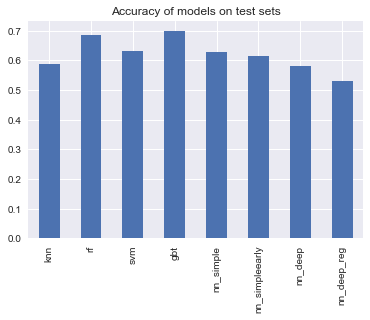

```python
row = accuracy_data.iloc[0]
row.plot(kind='bar')
plt.title('Accuracy of models on test sets')
plt.show()
```

#### ROC curve discrepancies

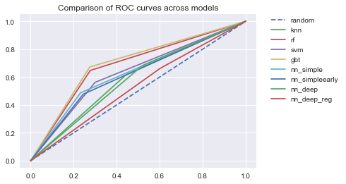

```python
# random
fpr_rand = tpr_rand = np.linspace(0, 1, 10)

#models
fpr_knn, tpr_knn, thresholds_knn = roc_curve(final_preds['actual'], final_preds['knn'])
fpr_rf, tpr_rf, thresholds_rf = roc_curve(final_preds['actual'], final_preds['rf'])
fpr_svm, tpr_svm, thresholds_svm = roc_curve(final_preds['actual'], final_preds['svm'])
fpr_gbt, tpr_gbt, thresholds_gbt = roc_curve(final_preds['actual'], final_preds['gbt'])
fpr_nn_simple, tpr_nn_simple, thresholds_nn_simple = roc_curve(final_preds['actual'], final_preds['nn_simple'])
fpr_nn_simpleearly, tpr_nn_simpleearly, thresholds_nn_simpleearly = roc_curve(final_preds['actual'], final_preds['nn_simpleearly'])
fpr_nn_deep, tpr_nn_deep, thresholds_nn_deep = roc_curve(final_preds['actual'], final_preds['nn_deep'])
fpr_nn_deep_reg, tpr_nn_deep_reg, thresholds_nn_deep_reg = roc_curve(final_preds['actual'], final_preds['nn_deep_reg'])

# plots
rocrand = plt.plot(fpr_rand, tpr_rand, linestyle='--', label="random")
roc1 = plt.plot(fpr_knn, tpr_knn, label="knn")
roc2 = plt.plot(fpr_rf, tpr_rf, label="rf")
roc3 = plt.plot(fpr_svm, tpr_svm, label="svm")
roc4 = plt.plot(fpr_gbt, tpr_gbt,label="gbt")
roc5 = plt.plot(fpr_nn_simple, tpr_nn_simple,label="nn_simple")
roc6 = plt.plot(fpr_nn_simpleearly, tpr_nn_simpleearly,label="nn_simpleearly")
roc7 = plt.plot(fpr_nn_deep, tpr_nn_deep,label="nn_deep")
roc8 = plt.plot(fpr_nn_deep_reg, tpr_nn_deep_reg,label="nn_deep_reg")

plt.legend(bbox_to_anchor=(1.05, 1), loc=2, borderaxespad=0.)
plt.title('Comparison of ROC curves across models')
plt.show()
```

```python
print("[INFO] AUC SCORE KNN {:.2f} ".format(roc_auc_score(labels_test, final_preds['knn'])))
print("[INFO] AUC SCORE RF {:.2f} ".format(roc_auc_score(labels_test, final_preds['rf'])))
print("[INFO] AUC SCORE SVM {:.2f} ".format(roc_auc_score(labels_test, final_preds['svm'])))
print("[INFO] AUC SCORE GBT {:.2f} ".format(roc_auc_score(labels_test, final_preds['gbt'])))
print("[INFO] AUC SCORE NN_SIMPLE {:.2f} ".format(roc_auc_score(labels_test, final_preds['nn_simple'])))
print("[INFO] AUC SCORE NN_SIMPLE_EARLY {:.2f} ".format(roc_auc_score(labels_test, final_preds['nn_simpleearly'])))
print("[INFO] AUC SCORE NN_DEEP {:.2f} ".format(roc_auc_score(labels_test, final_preds['nn_deep'])))
print("[INFO] AUC SCORE NN_DEEP_REG {:.2f} ".format(roc_auc_score(labels_test, final_preds['nn_deep_reg'])))
```

```
[INFO] AUC SCORE KNN 0.59
[INFO] AUC SCORE RF 0.68
[INFO] AUC SCORE SVM 0.63
[INFO] AUC SCORE GBT 0.70
[INFO] AUC SCORE NN_SIMPLE 0.63
[INFO] AUC SCORE NN_SIMPLE_EARLY 0.62
[INFO] AUC SCORE NN_DEEP 0.58
[INFO] AUC SCORE NN_DEEP_REG 0.53
```

```python
print("[INFO] CLASSIFICATION REPORT KNN")
print(classification_report(y_true=final_preds['actual'],y_pred=final_preds['knn']))

print("[INFO] CLASSIFICATION REPORT RF")
print(classification_report(y_true=final_preds['actual'],y_pred=final_preds['rf']))

print("[INFO] CLASSIFICATION REPORT SVM")
print(classification_report(y_true=final_preds['actual'],y_pred=final_preds['svm']))

print("[INFO] CLASSIFICATION REPORT GBT")
print(classification_report(y_true=final_preds['actual'],y_pred=final_preds['gbt']))

print("[INFO] CLASSIFICATION REPORT NN_SIMPLE")
print(classification_report(y_true=final_preds['actual'],y_pred=final_preds['nn_simple']))

print("[INFO] CLASSIFICATION REPORT NN_SIMPLE_EARLY")
print(classification_report(y_true=final_preds['actual'],y_pred=final_preds['nn_simpleearly']))

print("[INFO] CLASSIFICATION REPORT NN_DEEP")
print(classification_report(y_true=final_preds['actual'],y_pred=final_preds['nn_deep']))

print("[INFO] CLASSIFICATION REPORT NN_DEEP_REG")
print(classification_report(y_true=final_preds['actual'],y_pred=final_preds['nn_deep_reg']))
```

```
[INFO] CLASSIFICATION REPORT KNN
             precision    recall  f1-score   support

          0       0.59      0.56      0.57       400
          1       0.58      0.62      0.60       400

avg / total       0.59      0.59      0.59       800

[INFO] CLASSIFICATION REPORT RF
             precision    recall  f1-score   support

          0       0.67      0.72      0.70       400
          1       0.70      0.65      0.67       400

avg / total       0.69      0.69      0.68       800

[INFO] CLASSIFICATION REPORT SVM
             precision    recall  f1-score   support

          0       0.62      0.70      0.65       400
          1       0.65      0.56      0.60       400

avg / total       0.63      0.63      0.63       800

[INFO] CLASSIFICATION REPORT GBT
             precision    recall  f1-score   support

          0       0.69      0.72      0.71       400
          1       0.71      0.67      0.69       400

avg / total       0.70      0.70      0.70       800

[INFO] CLASSIFICATION REPORT NN_SIMPLE
             precision    recall  f1-score   support

          0       0.60      0.77      0.67       400
          1       0.68      0.49      0.57       400

avg / total       0.64      0.63      0.62       800

```

[output cut: 8 more lines]

```
[INFO] CLASSIFICATION REPORT NN_DEEP
             precision    recall  f1-score   support

          0       0.60      0.48      0.53       400
          1       0.57      0.68      0.62       400

avg / total       0.58      0.58      0.58       800

[INFO] CLASSIFICATION REPORT NN_DEEP_REG
             precision    recall  f1-score   support

          0       0.54      0.40      0.46       400
          1       0.52      0.66      0.58       400

avg / total       0.53      0.53      0.52       800
```

### Summary across results.

We can see that both tree based models did pretty well with high AUC scores and good ROC curve tradeoffs. We would probably settle on the tree based approach of GBT in the end.

Our NN were pretty weak out of the test set. We clearly need to increase the size of our training data to really get good accuracy.

This has the added impact as well of preventing us from going too deep in depth, as evidenced by the negative correlation.

I want to try one last approach, and that's ensembling our predictions.

### Ensembled trees

Let's ensemble four different models with a simple majority wins approach.

GBT, RF, NN_Simple & SVM approach.

```python
final_preds.head(15)
```

|  | actual | knn | rf | nn_simple | nn_simpleearly | nn_deep | nn_deep_reg | svm | gbt |
| --- | --- | --- | --- | --- | --- | --- | --- | --- | --- |
| 0 | 1 | 0 | 1 | 0 | 0 | 1 | 1 | 1 | 1 |
| 1 | 1 | 0 | 0 | 1 | 1 | 1 | 1 | 1 | 0 |
| 2 | 0 | 0 | 0 | 0 | 0 | 1 | 0 | 0 | 0 |
| 3 | 1 | 0 | 1 | 1 | 0 | 1 | 0 | 0 | 1 |
| 4 | 1 | 1 | 1 | 0 | 0 | 0 | 0 | 1 | 1 |
| 5 | 1 | 1 | 1 | 1 | 1 | 0 | 1 | 1 | 0 |
| 6 | 0 | 1 | 0 | 0 | 0 | 0 | 1 | 0 | 0 |
| 7 | 1 | 1 | 0 | 1 | 0 | 1 | 0 | 1 | 0 |
| 8 | 1 | 0 | 0 | 0 | 0 | 1 | 1 | 1 | 0 |
| 9 | 1 | 1 | 1 | 1 | 1 | 1 | 1 | 1 | 1 |
| 10 | 0 | 1 | 1 | 0 | 1 | 1 | 1 | 1 | 1 |
| 11 | 1 | 0 | 0 | 0 | 1 | 1 | 0 | 0 | 0 |
| 12 | 1 | 0 | 0 | 0 | 0 | 1 | 0 | 0 | 0 |
| 13 | 0 | 0 | 0 | 0 | 0 | 0 | 1 | 0 | 0 |
| 14 | 0 | 1 | 1 | 1 | 0 | 1 | 1 | 1 | 1 |

```python
final_preds['ensemble'] = pd.to_numeric(final_preds[['rf','nn_simple','svm','gbt']].mode(axis=1)[0])
# final_preds[['rf','nn_simple','svm','gbt']].mode(axis=1)[0]
final_preds.head()
```

|  | actual | knn | rf | nn_simple | nn_simpleearly | nn_deep | nn_deep_reg | svm | gbt | ensemble |
| --- | --- | --- | --- | --- | --- | --- | --- | --- | --- | --- |
| 0 | 1 | 0 | 1 | 0 | 0 | 1 | 1 | 1 | 1 | 1.0 |
| 1 | 1 | 0 | 0 | 1 | 1 | 1 | 1 | 1 | 0 | 0.0 |
| 2 | 0 | 0 | 0 | 0 | 0 | 1 | 0 | 0 | 0 | 0.0 |
| 3 | 1 | 0 | 1 | 1 | 0 | 1 | 0 | 0 | 1 | 1.0 |
| 4 | 1 | 1 | 1 | 0 | 0 | 0 | 0 | 1 | 1 | 1.0 |

```python
accuracy_score(y_true=final_preds['actual'], y_pred=final_preds['ensemble'])
```

```
0.67249999999999999
```

### Comments on ensemble

We can see that the ensembling approach did not lead to an improvement in accuracy.

This is enough for us to not proceed further. Still, ensembling can help to reduce specific bias in the test set, and can be a helpful tool!

### For fun, let's take a quick look at some images where the predictions differed.

```python
final_preds.head(15)
```

|  | actual | knn | rf | nn_simple | nn_simpleearly | nn_deep | nn_deep_reg | svm | gbt | ensemble |
| --- | --- | --- | --- | --- | --- | --- | --- | --- | --- | --- |
| 0 | 1 | 0 | 1 | 0 | 0 | 1 | 1 | 1 | 1 | 1.0 |
| 1 | 1 | 0 | 0 | 1 | 1 | 1 | 1 | 1 | 0 | 0.0 |
| 2 | 0 | 0 | 0 | 0 | 0 | 1 | 0 | 0 | 0 | 0.0 |
| 3 | 1 | 0 | 1 | 1 | 0 | 1 | 0 | 0 | 1 | 1.0 |
| 4 | 1 | 1 | 1 | 0 | 0 | 0 | 0 | 1 | 1 | 1.0 |
| 5 | 1 | 1 | 1 | 1 | 1 | 0 | 1 | 1 | 0 | 1.0 |
| 6 | 0 | 1 | 0 | 0 | 0 | 0 | 1 | 0 | 0 | 0.0 |
| 7 | 1 | 1 | 0 | 1 | 0 | 1 | 0 | 1 | 0 | 0.0 |
| 8 | 1 | 0 | 0 | 0 | 0 | 1 | 1 | 1 | 0 | 0.0 |
| 9 | 1 | 1 | 1 | 1 | 1 | 1 | 1 | 1 | 1 | 1.0 |
| 10 | 0 | 1 | 1 | 0 | 1 | 1 | 1 | 1 | 1 | 1.0 |
| 11 | 1 | 0 | 0 | 0 | 1 | 1 | 0 | 0 | 0 | 0.0 |
| 12 | 1 | 0 | 0 | 0 | 0 | 1 | 0 | 0 | 0 | 0.0 |
| 13 | 0 | 0 | 0 | 0 | 0 | 0 | 1 | 0 | 0 | 0.0 |
| 14 | 0 | 1 | 1 | 1 | 0 | 1 | 1 | 1 | 1 | 1.0 |

```python
test_images[4]
```

```
'data/test/dog/dog.1446.jpg'
```

```python
img = load_img(test_images[4])
```

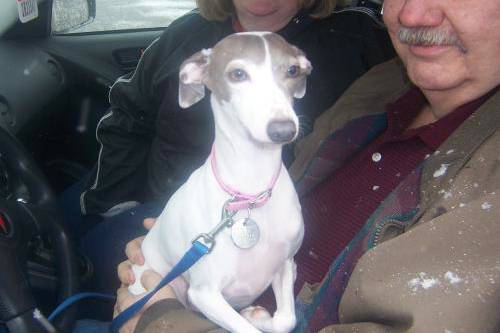

```python
img
```

Perhaps this dogs slightness and head shape lead to the inaccuracy of predictions!

```python
img = load_img(test_images[12])
```

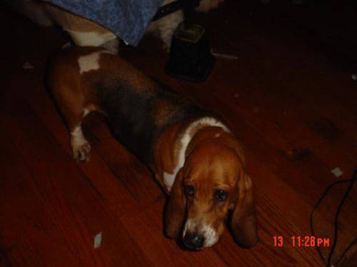

```python
img
```

This adorable hound is clearly a dog! Perhaps the color scale (we did not use greyscale) as well as the bed behind him made specific features hard to find.